# testing CLT theorem

Jonathan Bouchet

November 21, 2015

**Instructions :** In this project you will investigate the exponential distribution in R and compare it with the Central Limit Theorem. The exponential distribution can be simulated in R with rexp(n, lambda) where lambda is the rate parameter. The mean of exponential distribution is 1/lambda and the standard deviation is also 1/lambda. Set lambda = 0.2 for all of the simulations. You will investigate the distribution of averages of 40 exponentials. Note that you will need to do a thousand simulations.

Illustrate via simulation and associated explanatory text the properties of the distribution of the mean of 40 exponentials. You should :

1. Show the sample mean and compare it to the theoretical mean of the distribution.
2. Show how variable the sample is (via variance) and compare it to the theoretical variance of the distribution.
3. Show that the distribution is approximately normal.

In point 3, focus on the difference between the distribution of a large collection of random exponentials and the distribution of a large collection of averages of 40 exponentials.

**Recall of Central Limit Theorem** the CLT states that the distribution of averages of iid variables (properly normalized) becomes that of a standard normal as the sample size increases

**Organization of the document :** in the first part I do the simulations with the desired settings, in order to answer question 1. and 2. then I change the simulations parameter (nSims, n) to show how the distribution converges to a Normal distribution.

#### *Full simulation*

As we need to get the mean per simulation, using sapply will simplify to get the results. We also set the seed to reproduce the results.

```r
nosim <- 1000
n <- 40;
lambda <- 0.2
## create a matrix with 1000 simulations each with 40 rexp generated
set.seed(123456)
simudata <- matrix(rexp(nosim * n, lambda), nosim);
## get the mean of the 40 distribution, for each simu
simudata_mean <- apply(simudata, 1, mean);
mean(simudata_mean)
```

```
## [1] 5.022915
```

```r
var(simudata_mean)
```

```
## [1] 0.6557463
```

```r
sd(simudata_mean)
```

```
## [1] 0.8097816
```

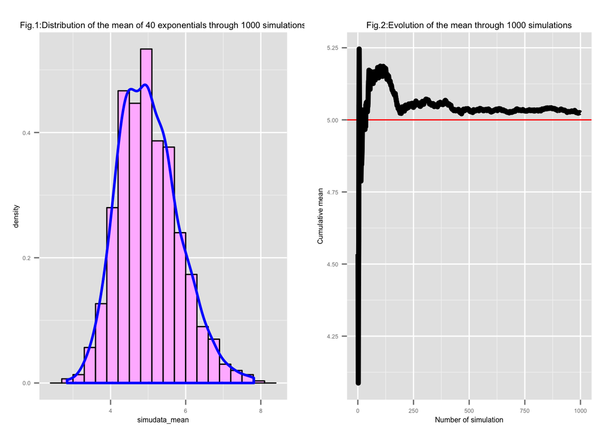

```r
library(ggplot2)
plotdata <- data.frame(simudata_mean);
m <- ggplot(plotdata, aes(x = simudata_mean));
m <- m + geom_histogram(aes(y=..density..),binwidth=.3, colour="black", fill = "plum1")
m <- m + geom_density(colour="blue", size=1);
m <- m + ggtitle("Fig.1:Distribution of the mean of 40 exponentials through 1000 simulations")
m <- m + theme(text=element_text(size=6))

meantempo<-cumsum(simudata_mean)/(1:nosim)
g <- ggplot(data.frame(x = 1:nosim, y = meantempo), aes(x = x, y = y))
g <- g + geom_hline(colour="red",yintercept = 5) + geom_line(size = 2)
g <- g + labs(x = "Number of simulation", y = "Cumulative mean")
g <- g + ggtitle("Fig.2:Evolution of the mean through 1000 simulations")
g <- g + theme(text=element_text(size=6))

library(gridExtra)
# arrange both plots
grid.arrange(m,g,ncol=2, nrow=1)
```

#### *Results and Comments*

First we see from $\textbf{Fig. 1}$ looks like a normal distribution. In details (from the printing at the R console) :

1. the center of the resulting distribution (5.022915) is indeed very close to the expected center ($\mu$ = 1/$\lambda$ = 5.0)
2. the variance (0.6557463) is closed to the expected variance ($\sigma^{2}/n)$ = $1/\lambda^{2}/n)$ = 0.625)
3. the standard deviation, as the square root of the variance(0.8097816) is closed to the expected variance ($\sqrt(0.625)$ = 0.790)
4. it is also interesting to see how behaves the mean through the simulation ($\textbf{Fig. 2}$). We see that even with nosim =1000 the mean does not converge exactly the expected mean (symbolized by the red line)

For a large sample, the CLT approximates $\bar X_{n}$ to $N(\mu,\sigma^{2}/n)$.

#### *Studies*

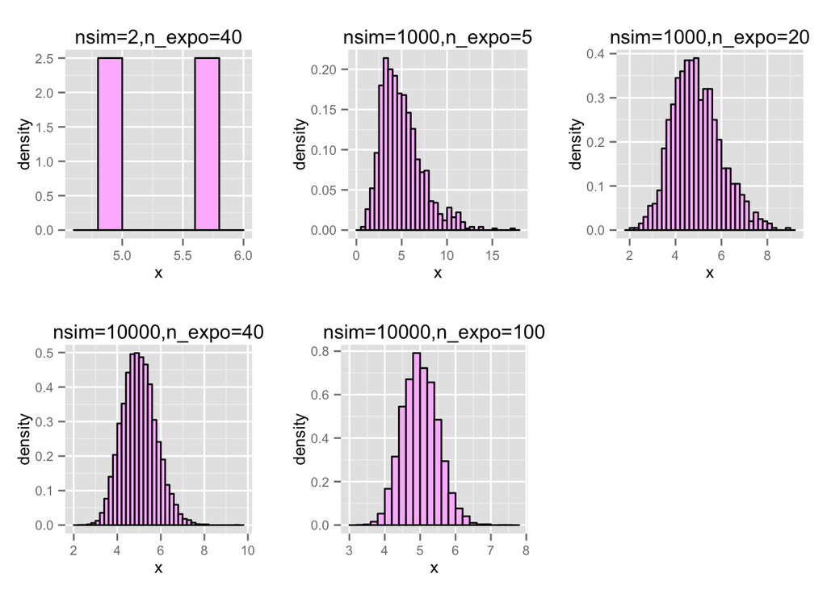

#### *Results and Comments*

1. The 3 plots on the top shows how the distribution of the mean looks like for a small number of simulations and/or low number of exponentials per simulation. Even with a low number of exponentials (5) for 1000 simulations, the distribution is not quite gaussian
2. The 2 plots on the bottom show the results for larger simulation. At the extreme case (nosim=1e4,100 exponentials per simulation), we reach a pretty good normal distribution